# Practicing Data Wrangling with Tree Equity Data

Author

Jo Hardin – AWM + GEM

Published

```r
library(tidyverse)
```

## Instructions

In this worksheet, you’ll practice writing **ggplot R code** for creating data visualizations. Each question guides you through building layers of plots for the `ca_tes` dataset.

**Don’t stress yourself out over perfect syntax** – the goal is to practice what you’ve learned about data wrangling so far.

# The Data

## Loading in the data

```r
ca_tes <- tempfile(fileext = ".zip") |>
  (\(f) {
    download.file("https://tes-app-data-share.s3.amazonaws.com/ca/ca_csv.zip", f, quiet = TRUE)
    read_csv(unz(f, unzip(f, list = TRUE)$Name[1]))
  })()
```

## Looking at the data

```r
ca_tes
```

```
# A tibble: 24,253 × 48
   GEOID place state state_abbr county ua_name ua_pop congressio cbg_pop acs_pop
   <chr> <chr> <chr> <chr>      <chr>  <chr>    <dbl> <chr>        <dbl>   <dbl>
 1 0600… Oakl… Cali… CA         Alame… San Fr… 3.52e6 CA Congre…    1789    1963
 2 0600… Oakl… Cali… CA         Alame… San Fr… 3.52e6 CA Congre…    1249    1361
 3 0600… Oakl… Cali… CA         Alame… San Fr… 3.52e6 CA Congre…    1022    1029
 4 0600… Oakl… Cali… CA         Alame… San Fr… 3.52e6 CA Congre…     979    1009
 5 0600… Oakl… Cali… CA         Alame… San Fr… 3.52e6 CA Congre…    1123    1122
 6 0600… Oakl… Cali… CA         Alame… San Fr… 3.52e6 CA Congre…    1528    1623
 7 0600… Oakl… Cali… CA         Alame… San Fr… 3.52e6 CA Congre…    1390    1048
 8 0600… Oakl… Cali… CA         Alame… San Fr… 3.52e6 CA Congre…    1463    1656
 9 0600… Oakl… Cali… CA         Alame… San Fr… 3.52e6 CA Congre…    1558    1489
10 0600… Oakl… Cali… CA         Alame… San Fr… 3.52e6 CA Congre…    1353    1035
# ℹ 24,243 more rows
# ℹ 38 more variables: land_area <dbl>, biome <chr>, cnpysource <chr>,
#   tc_goal <dbl>, treecanopy <dbl>, tc_gap <dbl>, priority_i <dbl>,
#   pctpoc <dbl>, pctpocnorm <dbl>, pctpov <dbl>, pctpovnorm <dbl>,
#   unemplrate <dbl>, unemplnorm <dbl>, dep_ratio <dbl>, dep_perc <dbl>,
#   depratnorm <dbl>, linguistic <dbl>, lingnorm <dbl>, health_nor <dbl>,
#   temp_diff <dbl>, temp_norm <dbl>, tes <dbl>, tesctyscor <dbl>, …
```

Variable descriptions are given (mostly) at https://www.treeequityscore.org/methodology?tab=data-glossary

## An observation

> Observational Unit: object by which data is collected and analyzed

For example, an observational unit could be any of the following:

- Person
- County
- State
- Country
- *What is the observational unit in the tree equity dataset?*

## What is the observational unit?

```r
ca_tes
```

```
# A tibble: 24,253 × 48
   GEOID place state state_abbr county ua_name ua_pop congressio cbg_pop acs_pop
   <chr> <chr> <chr> <chr>      <chr>  <chr>    <dbl> <chr>        <dbl>   <dbl>
 1 0600… Oakl… Cali… CA         Alame… San Fr… 3.52e6 CA Congre…    1789    1963
 2 0600… Oakl… Cali… CA         Alame… San Fr… 3.52e6 CA Congre…    1249    1361
 3 0600… Oakl… Cali… CA         Alame… San Fr… 3.52e6 CA Congre…    1022    1029
 4 0600… Oakl… Cali… CA         Alame… San Fr… 3.52e6 CA Congre…     979    1009
 5 0600… Oakl… Cali… CA         Alame… San Fr… 3.52e6 CA Congre…    1123    1122
 6 0600… Oakl… Cali… CA         Alame… San Fr… 3.52e6 CA Congre…    1528    1623
 7 0600… Oakl… Cali… CA         Alame… San Fr… 3.52e6 CA Congre…    1390    1048
 8 0600… Oakl… Cali… CA         Alame… San Fr… 3.52e6 CA Congre…    1463    1656
 9 0600… Oakl… Cali… CA         Alame… San Fr… 3.52e6 CA Congre…    1558    1489
10 0600… Oakl… Cali… CA         Alame… San Fr… 3.52e6 CA Congre…    1353    1035
# ℹ 24,243 more rows
# ℹ 38 more variables: land_area <dbl>, biome <chr>, cnpysource <chr>,
#   tc_goal <dbl>, treecanopy <dbl>, tc_gap <dbl>, priority_i <dbl>,
#   pctpoc <dbl>, pctpocnorm <dbl>, pctpov <dbl>, pctpovnorm <dbl>,
#   unemplrate <dbl>, unemplnorm <dbl>, dep_ratio <dbl>, dep_perc <dbl>,
#   depratnorm <dbl>, linguistic <dbl>, lingnorm <dbl>, health_nor <dbl>,
#   temp_diff <dbl>, temp_norm <dbl>, tes <dbl>, tesctyscor <dbl>, …
```

- The GEOID or census block group describes a particular community or neighborhood in a given area that contains between 600 - 3,000 people [^1]

## What are the variables?

- `treecanopy`: actual tree coverage in an area
- `tc_goal`: ideal tree coverage based on needs
- `tc_gap`: how far behind the area is (`tc_goal` - `treecanopy`)
- `pctpocnorm`: % residents who are people of color
- `pctpovnorm`, `unemplnorm`: indicators of equity
- `lingnorm`: % of non-English households (linguistic isolation)
- `tes`: tree equity score (gap × need)

## 1. Tree Equity vs. Poverty

> Is there a relationship between poverty (`pctpov`) and tree equity score (`tes`)?

```r
ca_tes |>
  ___(___(x = ___, y = ___)) +
  ___(color = "navy", alpha = 0.05)
```

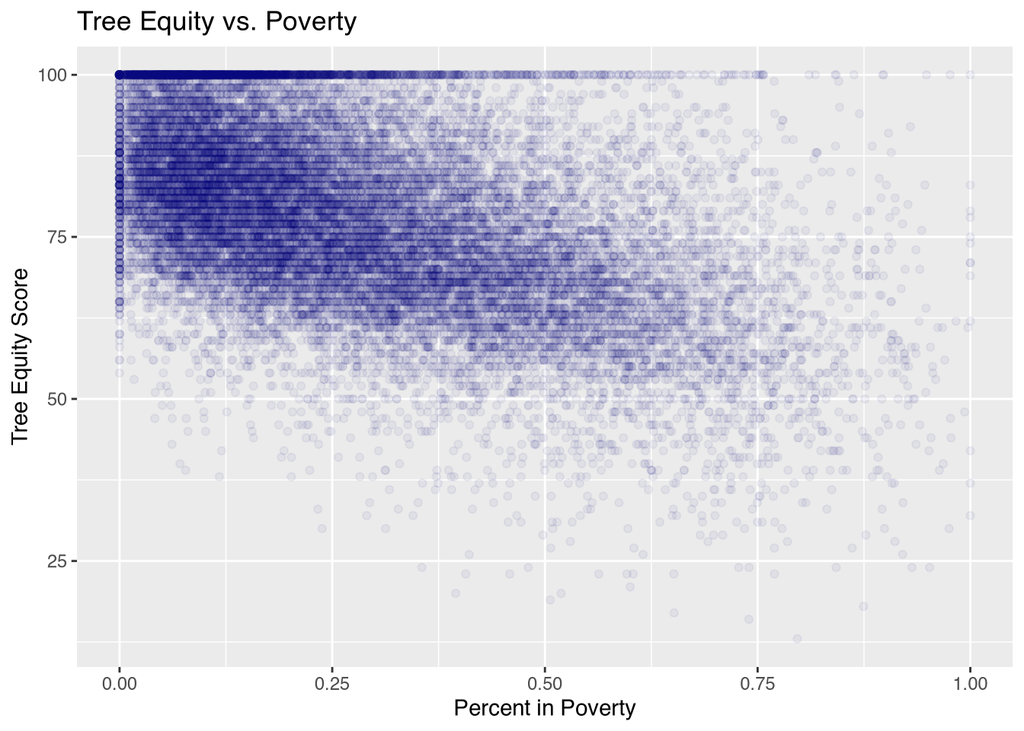

```r
ca_tes |>
  ggplot(aes(x = pctpov, y = tes)) +
  geom_point(color = "navy", alpha = 0.05) +
  labs(title = "Tree Equity vs. Poverty",
       x = "Percent in Poverty",
       y = "Tree Equity Score")
```

## 2. Distribution of tree equity scores

> What is the distribution of tree equity scores (`tes`)?

```r
___ |>
  ggplot(aes(___)) +
  ___(fill = "red")
```

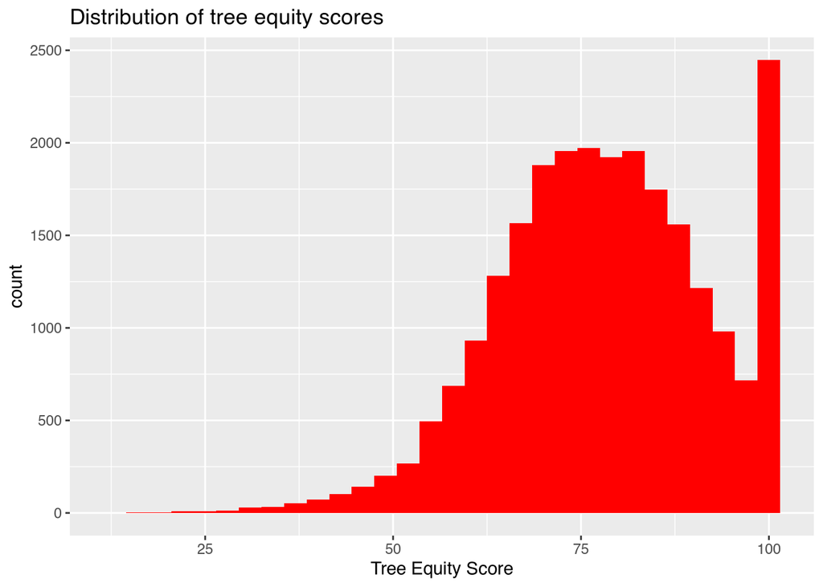

```r
ca_tes |>
  ggplot(aes(x = tes)) +
  geom_histogram(fill = "red") +
  labs(title = "Distribution of tree equity scores",
       x = "Tree Equity Score")
```

## 3. Distribution of tree equity scores

> What is the distribution of tree equity scores (`tes`) created by a boxplot?

```r
___ |>
  ggplot(aes(___)) +
  ___(fill = "violet")
```

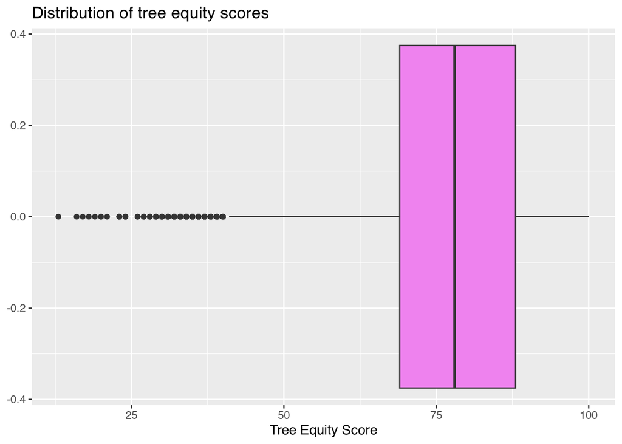

```r
ca_tes |>
  ggplot(aes(x = tes)) +
  geom_boxplot(fill = "violet") +
  labs(title = "Distribution of tree equity scores",
       x = "Tree Equity Score")
```

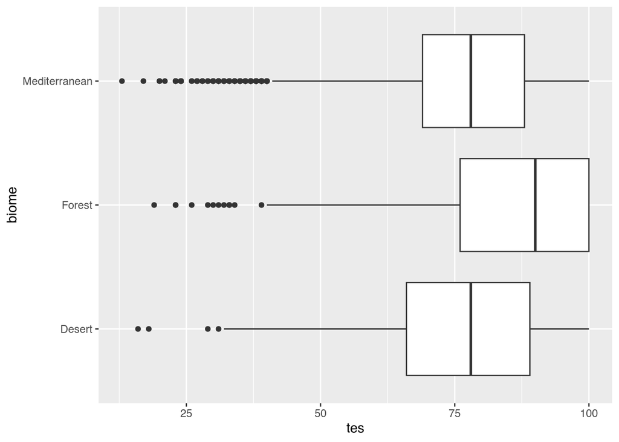

```r
ca_tes |>
  ggplot(aes(x = tes, y = biome)) +
  geom_boxplot()
```

## 4. Tree equity vs. linguistic isolation

> Is there a relationship between linguistic isolation (`lingnorm`) and `tes` in an area.
- Use ggplot to plot the relationship between `tes` and `lingnorm`
- Choose the best plot for the variable types
- Create fitting labels for your axes and plot title

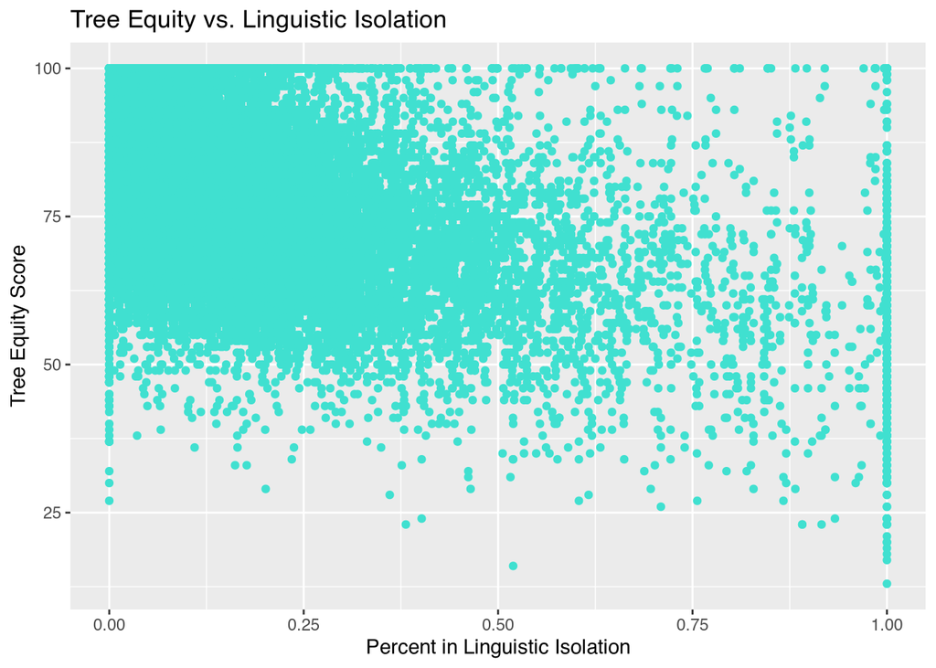

```r
ca_tes |>
  ggplot(aes(x = lingnorm, y = tes)) +
  geom_point(color = "turquoise") +
  labs(title = "Tree Equity vs. Linguistic Isolation",
       x = "Percent in Linguistic Isolation",
       y = "Tree Equity Score")
```

## 5. Wrangle + plot

Recreate the plot above, but summarize the information **per `county`** before plotting. That is, `Los Angeles County` should now only be represented by one dot. Summarize both `lingnorm` and `tes` using the `mean()` function.

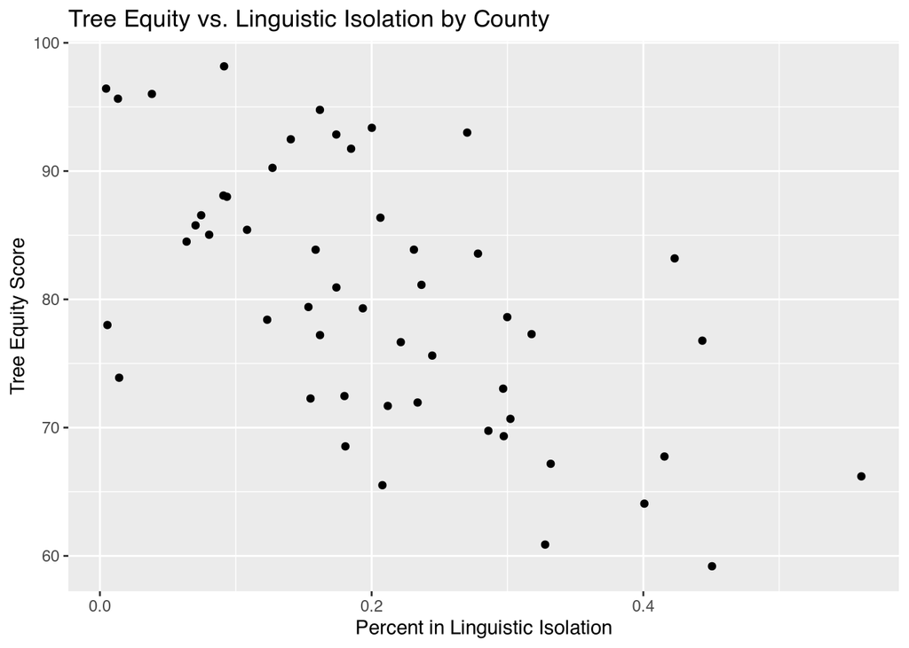

```r
ca_tes |>
  group_by(county) |>
  summarize(ave_ling = mean(lingnorm),
            ave_tes = mean(tes)) |>
  ggplot(aes(x = ave_ling, y = ave_tes)) +
  geom_point() +
  labs(title = "Tree Equity vs. Linguistic Isolation by County",
       x = "Percent in Linguistic Isolation",
       y = "Tree Equity Score")
```

## 6. Wrangle + plot + label

Recreate the plot above, but now add labels to the plot to indicate the county of each dot. Use `geom_label()` or `geom_text()`. Try both! You’ll need to use `label = county`… do you need `aes()`?

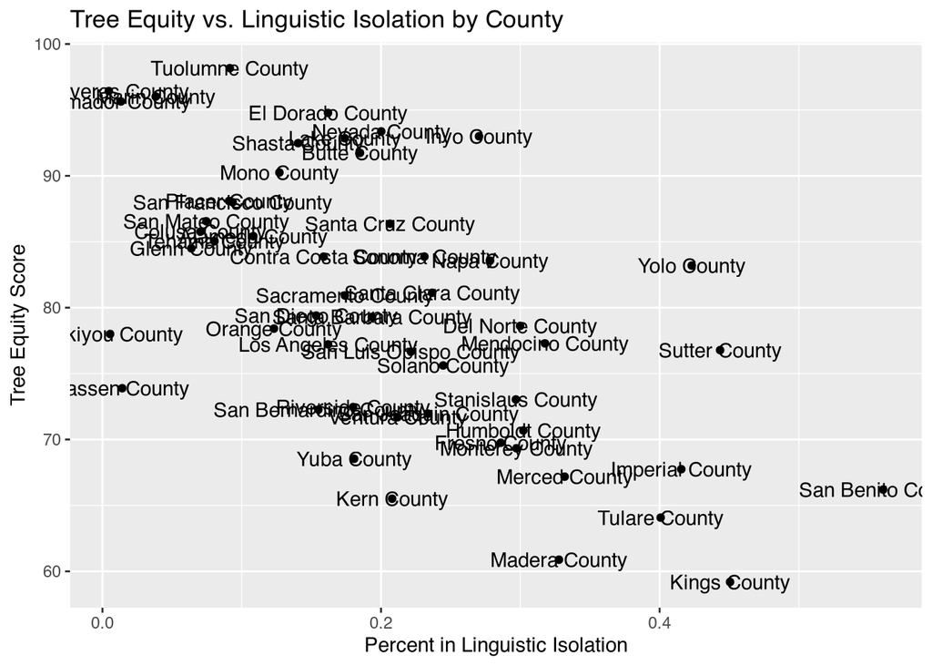

```r
ca_tes |>
  group_by(county) |>
  summarize(ave_ling = mean(lingnorm),
            ave_tes = mean(tes)) |>
  ggplot(aes(x = ave_ling, y = ave_tes)) +
  geom_point() +
  geom_text(aes(label = county)) +
  labs(title = "Tree Equity vs. Linguistic Isolation by County",
       x = "Percent in Linguistic Isolation",
       y = "Tree Equity Score")
```

## 7. Wrangle + plot + label

There is an R package called **ggrepel**. It includes a geom called `geom_label_repel`. Try it! (To use a function from a package, you can write: `ggrepel::geom_label_repel()`.)

**Hint:** Is there a yellow bar at the top asking if you want to load the R package **ggrepel**? Say yes!

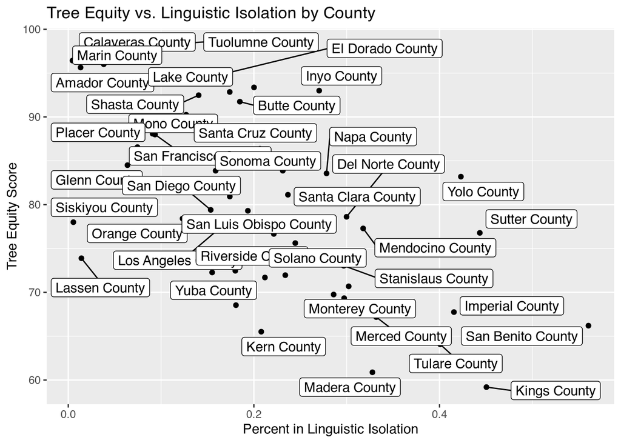

```r
ca_tes |>
  group_by(county) |>
  summarize(ave_ling = mean(lingnorm),
            ave_tes = mean(tes)) |>
  ggplot(aes(x = ave_ling, y = ave_tes)) +
  geom_point() +
  ggrepel::geom_label_repel(aes(label = county)) +
  labs(title = "Tree Equity vs. Linguistic Isolation by County",
       x = "Percent in Linguistic Isolation",
       y = "Tree Equity Score")
```

# Explore, Analyze, Present!

## Your turn

> You will work in small groups to investigate tree equity in a new state(s)
- **Each group will:**
- Choose a research question(s)
- Use tidyverse wrangling tools to explore the data
- Create plot(s) with **ggplot2**

## Your goals

- Clearly state your research question
- Support your question with R code and graphs
- Use the data to identify a trend, pattern, or disparity
- Communicate **WHY** it matters

## Sample questions

- How does tree canopy vary across different neighborhoods in *chosen state*?
- Is there a relationship between percent in poverty and tree equity score in *chosen state*?
- How do tree equity trends compare between two or more *chosen states*?
- Are places with lower tree equity also more likely to have higher health disparities in *chosen state*?
- What if you break down / `summarize()` the information by county?

## Getting the data

**Navigate to https://www.treeequityscore.org/:**

- in drop down menu, click the “methods and data” tab
- choose the “data download” page
- choose the state of interest, and load in the data using the code from the very top of this document (but replace `ca` twice with the two-digit letters for your state)

# Independent Practice

## 1. Tree Equity vs. Poverty

> Is there a relationship between poverty (`pctpov`) and tree equity score (`tes`)?

```r
ca_tes |>
  ___(___(x = ___, y = ___)) +
  ___(color = "green")
```

## 2. Distribution of tree equity scores

> What is the distribution of tree equity scores (`tes`)?

```r
___ |>
  ggplot(aes(___)) +
  ___(fill = "red")
```

## 3. Distribution of tree equity scores

> What is the distribution of tree equity scores (`tes`) created by a boxplot?

```r
___ |>
  ggplot(aes(___)) +
  ___(fill = "violet")
```

## 4. Tree equity vs. linguistic isolation

> Is there a relationship between linguistic isolation(`lingnorm`) and `tes` in an area.
- Use ggplot to plot the relationship between `tes` and `lingnorm`
- Choose the best plot for the variable types
- Create fitting labels for your axes and plot title

## 5. Wrangle + plot

Recreate the plot above, but summarize the information **per `county`** before plotting. That is, `Los Angeles County` should now only be represented by one dot. Summarize both `lingnorm` and `tes` using the `mean()` function.

## 6. Wrangle + plot + label

Recreate the plot above, but now add labels to the plot to indicate the county of each dot. Use `geom_label()` or `geom_text()`. Try both! You’ll need to use `label = county`… do you need `aes()`?

## 7. Wrangle + plot + label

There is an R package called **ggrepel**. It includes a geom called `geom_label_repel`. Try it! (To use a function from a package, you can write: `ggrepel::geom_label_repel()`.)

**Hint:** If R can’t find the **ggrepel** package, you may need to type `install.packages("ggrepel")` in the Console down below.

## Footnotes

[^1]: American Forests Methods and Data Glossary. https://www.treeequityscore.org/methodology?tab=data-glossary